# Designing simulation studies in R

James E. Pustejovsky

# 1 Purpose

Computer simulations are an essential tool of inquiry for statisticians and quantitative methodologists, useful both for small-scale or informal investigations and for formal methodological research (i.e., the sort of work you might present at a conference, in a research paper, or for your dissertation). Simulation studies involve investigating the performance of a statistical model or method under known data-generating processes. By controlling the data-generating process (e.g., specifying true values for the parameters of a statistical model) and then repeatedly applying a statistical method to data generated by that process, it becomes possible to assess the accuracy of the method (or other aspects of the method’s performance). Simulations are used to address a range of questions:

- Many statistical estimation procedures can be shown (through mathematical analysis) to work well *asymptotically*—that is, given an infinite amount of data—but their performance in small samples is more difficult to quantify. Simulation is a tractable approach for assessing the small-sample performance of such methods, or for determining minimum required sample sizes for adequate performance of a method. For example, heteroskedasticity-robust standard errors (HRSE) are known to work asymptotically, but can be misleading in small samples. Long and Ervin (2000) investigate the performance of HRSE for a range of sample sizes, demonstrating that the most commonly used form of these estimators often does NOT work well with sample sizes typical in the social sciences.
- In practice, statistical methods are often used in combination. For instance, in a regression model, one could first use a statistical test for heteroskedasticity (e.g., the White test or the Breusch-Pagan test) and then determine whether to use conventional standard errors or HRSE depending on the result of the test. This combination of an initial diagnostic test followed by contingent use of different statistical procedures is all but impossible to analyze mathematically, but it is straight-forward to simulate (again, see Long & Ervin, 2000).
- Many statistical estimation procedures can be shown (through mathematical analysis) to perform well when the assumptions they entail are correct. However, it practice it is often of interest to also understand their robustness—that is, their performance when one or more of the assumptions is incorrect.
- There may be several potential methods available for conducting a certain analysis. Simulation is a useful way to determine whether some methods are superior to others. For instance, Brown and Forsythe (1974) compared four different procedures for conducting a hypothesis test for equality of means in several populations (i.e., one-way ANOVA), but where the population variances are not equal.

Here we’ll start to look at how to design simulation studies for formal research.

# 2 Structure of a simulation study

We can think of simulation studies as involving five distinct pieces, as illustrated in the diagram below.

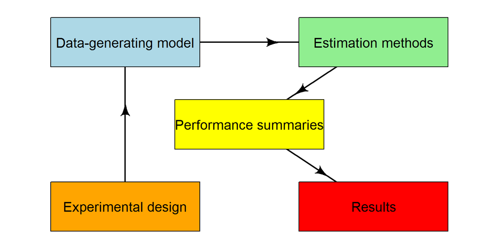

1. **Experimental design**. Simulation studies closely resemble designed experiments, in which factors such as sample size and true parameter values are systematically varied. Typically, simulation studies follow a **full factorial design**, in which each level of a factor is crossed with every other level. (We will look further at this aspect of simulation design in a later class.) The experimental design consists of sets of parameter values (including design parameters, such as sample sizes) that will be considered in the study.
2. **Data-generating model**. The data-generating model takes a set of parameter values as input and generates a set of simulated data as output.
3. **Estimation methods**. The estimation methods consist of the set of statistical procedures under examination. Each method takes a simulated dataset and produces a set of estimates or results (i.e., point estimates, standard errors, confidence intervals, p-values, etc.).
4. **Performance summaries**. Performance summaries are the metrics used to assess the performance of a statistical method. Interest usually centers on understanding the performance of a method over repeated samples from a data-generating process. Thus, we will need to repeat steps 2 and 3 many times to get a large number of simulated estimates. We then *summarize the distribution* of the estimates to characterize performance of a method.
5. **Results**. Simulation results consist of sets of performance metrics for every combination of parameter values in the experimental design. Thus, steps 2 through 4 will need to get repeated a bunch.

In writing R code to implement all these calculations, we will follow a **modular approach**, in which each component of the simulation is implemented *as a separate function* (or potentially a set of several functions). Writing separate functions for the different components of the simulation will make the code easier to read, test, and debug. Furthermore, it makes it possible to swap components of the simulation in or out, such as by adding additional estimation methods or trying out a data-generating model that involves different distributional assumptions. In the remainder of these notes, we’ll look at the structure of the functions for implementing steps 2 and 3 of the simulation process. (We’ll look at steps 1, 4, and 5 in detail in later classes.)

# 3 Heteroskedasticity ANOVA

To illustrate the process of programming a simulation, let’s look at the simulations from Brown and Forsythe (1974). These authors study methods for testing hypotheses in the following model. Consider a population consisting of $g$ separate groups, with population means $\mu_1,...,\mu_g$ and population variances $\sigma_1^2,...,\sigma_g^2$ for some characteristic $X$. We obtain samples of size $n_1,...,n_g$ from each of the groups, and take measurements of the characteristic for each unit in each group. Let $x_{ij}$ denote the measurement from unit $j$ in group $i$, for $i = 1,...,g$ and $j = 1,...,n_i$. Our goal is to use the sample data to test the hypothesis that the population means are all equal, i.e.,
$$H_0: \mu_1 = \mu_2 = \cdots = \mu_g.$$
Note that if the population variances were all equal (i.e., $\sigma_1^2 = \sigma_2^2 = \cdots = \sigma_g^2$), we could use a conventional one-way analysis of variance to test the hypothesis. However, one-way ANOVA might not work well if the variances are not equal.

Brown and Forsythe evaluated two different hypothesis testing procedures, developed by James (1951) and Welch (1951), that had been proposed for testing this hypothesis without assuming equality of variances. They also proposed and evaluated a new procedure of their own devising, and also studied the performance of the conventional one-way ANOVA F-test as a benchmark. The simulation involves comparing the performance of these different hypothesis testing procedures under a range of conditions.

The main performance metrics of interest were the type-I error rate (i.e., when the null hypothesis is true, how often does each test falsely reject the null?) and power (how often does the test correctly reject the null when it is indeed false?) of each test, for nominal $\alpha$-levels of 1%, 5%, and 10%. Table 1 of the paper reports the simulation results for type-I error (labeled as “size”); ideally, a test should have true type-I error very close to the nominal $\alpha$. Table 2 reports results on power; it is desirable to have higher power to reject null hypotheses that are false, so higher rates are better here.

# 4 Data-generating model

In the abstract, a function that implements a data-generating model should have the following form:

```r
generate_data <- function(parameters) {

  # simulations and calculations

  return(sim_data)
}
```

The function takes a set of parameter values as input, simulates random numbers and does calculations, and produces as output a set of simulated data. In practice, the parameters will typically consist of *multiple* values, including not only the model parameters, but also sample sizes and other study design parameters.

## 4.1 heteroskedastic ANOVA

In the heteroskedastic one-way ANOVA simulation, there are three sets of parameter values: population means, population variances, and sample sizes. To allow for the possibility of simulating an arbitrary number of groups, we can use vectors of length $g$ as inputs to the data-generating function:

```r
generate_data <- function(mu, sigma_sq, sample_size) {

  # simulations and calculations

  return(sim_data)
}
```

Now to fill in the function. Rather than attempting to write the function immediately, it is often easier to write code for a specific case first. For example, say that we have four groups with means of 1, 2, 5, 6; variances of 3, 2, 5, 1; and sample sizes of 3, 6, 2, and 4:

```r
mu <- c(1, 2, 5, 6)
sigma_sq <- c(3, 2, 5, 1)
sample_size <- c(3, 6, 2, 4)
```

Following Brown and Forsythe, we’ll assume that the measurements are normally distributed within each sub-group of the population. The following code generates a vector of group id’s and a vector of simulated measurements:

```r
N <- sum(sample_size) # total sample size
g <- length(sample_size) # number of groups

group <- rep(1:g, times = sample_size) # group id
mu_long <- rep(mu, times = sample_size) # mean for each unit of the sample
sigma_long <- rep(sqrt(sigma_sq), times = sample_size) # sd for each unit of the sample
cbind(group, mu_long, sigma_long)
```

```
##       group mu_long sigma_long
##  [1,]     1       1   1.732051
##  [2,]     1       1   1.732051
##  [3,]     1       1   1.732051
##  [4,]     2       2   1.414214
##  [5,]     2       2   1.414214
##  [6,]     2       2   1.414214
##  [7,]     2       2   1.414214
##  [8,]     2       2   1.414214
##  [9,]     2       2   1.414214
## [10,]     3       5   2.236068
## [11,]     3       5   2.236068
## [12,]     4       6   1.000000
## [13,]     4       6   1.000000
## [14,]     4       6   1.000000
## [15,]     4       6   1.000000
```

```r
x <- rnorm(N, mean = mu_long, sd = sigma_long)
data.frame(group = group, x = x)
```

```
##    group           x
## 1      1  2.31535890
## 2      1  0.53445090
## 3      1  0.75238491
## 4      2  0.06918187
## 5      2  2.68934585
## 6      2  3.11434855
## 7      2  3.12687043
## 8      2  1.52961602
## 9      2 -0.64326387
## 10     3  4.46773771
## 11     3  3.55086066
## 12     4  6.71756157
## 13     4  6.69222065
## 14     4  5.49814183
## 15     4  6.18649336
```

Now wrap this code in a function:

```r
generate_data <- function(mu, sigma_sq, sample_size) {

  N <- sum(sample_size)
  g <- length(sample_size)

  group <- rep(1:g, times = sample_size)
  mu_long <- rep(mu, times = sample_size)
  sigma_long <- rep(sqrt(sigma_sq), times = sample_size)

  x <- rnorm(N, mean = mu_long, sd = sigma_long)
  sim_data <- data.frame(group = group, x = x)

  return(sim_data)
}

generate_data(mu = mu, sigma_sq = sigma_sq, sample_size = sample_size)
```

```
##    group          x
## 1      1  1.4072805
## 2      1 -0.4115292
## 3      1 -1.6579959
## 4      2 -1.2270763
## 5      2  5.0062628
## 6      2  1.2659858
## 7      2  0.3264906
## 8      2  2.4795338
## 9      2  0.8804460
## 10     3  7.7567704
## 11     3  6.4221802
## 12     4  4.7637089
## 13     4  5.2856754
## 14     4  6.4036571
## 15     4  6.8384500
```

Re-run the function and we get a new set of simulated data:

```r
generate_data(mu = mu, sigma_sq = sigma_sq, sample_size = sample_size)
```

```
##    group          x
## 1      1  0.4797689
## 2      1  1.1314706
## 3      1 -1.1419139
## 4      2  1.4457870
## 5      2  1.6791162
## 6      2  1.7831461
## 7      2  2.2228329
## 8      2  1.0167233
## 9      2  4.2334181
## 10     3  4.3590971
## 11     3  5.8823352
## 12     4  6.7374450
## 13     4  6.9259798
## 14     4  4.8449703
## 15     4  6.0432656
```

## 4.2 Efficiency versus simplicity

An alternative approach to the above would be to write a function that generates *multiple* sets of simulated data all at once. For example, we could specify that we want `R` replications of the study and have the function spit out a matrix with `R` columns, one for each simulated dataset:

```r
generate_data_matrix <- function(mu, sigma_sq, sample_size, R) {

  N <- sum(sample_size)
  g <- length(sample_size)

  group <- rep(1:g, times = sample_size)
  mu_long <- rep(mu, times = sample_size)
  sigma_long <- rep(sqrt(sigma_sq), times = sample_size)

  x_mat <- matrix(rnorm(N * R, mean = mu_long, sd = sigma_long), nrow = N, ncol = R)
  sim_data <- list(group = group, x_mat = x_mat)

  return(sim_data)
}

generate_data_matrix(mu = mu, sigma_sq = sigma_sq, sample_size = sample_size, R = 4)
```

```
## $group
##  [1] 1 1 1 2 2 2 2 2 2 3 3 4 4 4 4
##
## $x_mat
##             [,1]         [,2]       [,3]     [,4]
##  [1,] -1.1564371 -1.040124215  0.4704632 1.530849
##  [2,]  0.7308586  0.001692595 -0.3849880 1.118591
##  [3,]  0.8523140 -0.379051184 -0.5892291 4.298125
##  [4,]  0.8765328  3.691188274  3.9415208 1.187048
##  [5,]  3.0746642  3.312569980  1.6352992 1.860789
##  [6,]  1.9720540  0.674150272  1.0117352 1.705420
##  [7,]  1.9089495  0.370199221  4.0206600 4.218816
##  [8,]  1.5904721  1.896934331  2.7878938 1.111495
##  [9,]  3.4792573  1.513413055  1.6132198 1.920342
## [10,]  7.7945734  8.164566946  7.7048386 4.743092
## [11,]  9.1386311  8.274597003  3.0469894 5.328514
## [12,]  5.8664305  6.392593051  4.7753535 6.480738
## [13,]  7.1991533  6.502808717  6.2990534 7.965857
## [14,]  5.8855285  7.491607792  6.3135694 5.937889
## [15,]  5.5682325  6.053052109  6.2984924 6.080189
```

This approach is a bit more computationally efficient because the setup calculations (getting `N`, `g`, `group`, `mu_full`, and `sigma_full`) only have to be done once instead of once per replication. It also makes clever use of vector recycling in the call to `rnorm()`. However, the structure of the resulting data is more complicated, which will make it more difficult to do the later estimation steps. Furthermore, if `R` is large and each replication produces a large dataset, this “all-at-once” approach will entail generating and holding very large amounts of data in memory, which can create other performance issues. On balance, I recommend following the simpler approach of writing a function that generates a single simulated dataset per call (unless and until you have a principled reason to do otherwise).

## 4.3 Checking the data-generating function

An important part of learning to program in R—particularly learning to write functions—is finding ways to test and check the correctness of your code. Thus, after writing a data-generating function, we need to consider how to test whether the output it produces is correct. How best to do this will depend on the data-generating model being implemented.

For the heteroskedastic ANOVA problem, one basic thing we could do is check that the simulated data from each group follows a normal distribution. By generating very large samples from each group, we can effectively check characteristics of the population distribution. In the following code, I simulate very large samples from each of the four groups, check that the means and variances agree with the input parameters, and check normality using QQ plots:

```r
check_data <- generate_data(mu = mu, sigma_sq = sigma_sq, sample_size = rep(10000, 4))

table(check_data$group) # check sample sizes
```

```
##
##     1     2     3     4
## 10000 10000 10000 10000
```

```r
with(check_data, tapply(x, group, mean)) # calculate means by group
```

```
##        1        2        3        4
## 0.988485 2.002397 4.971342 5.997743
```

```r
mu # compare to mean parameters
```

```
## [1] 1 2 5 6
```

```r
with(check_data, tapply(x, group, var)) # calculate variances by group
```

```
##         1         2         3         4
## 2.9843895 2.0164140 5.0020772 0.9783217
```

```r
sigma_sq # compare to variance parameters
```

```
## [1] 3 2 5 1
```

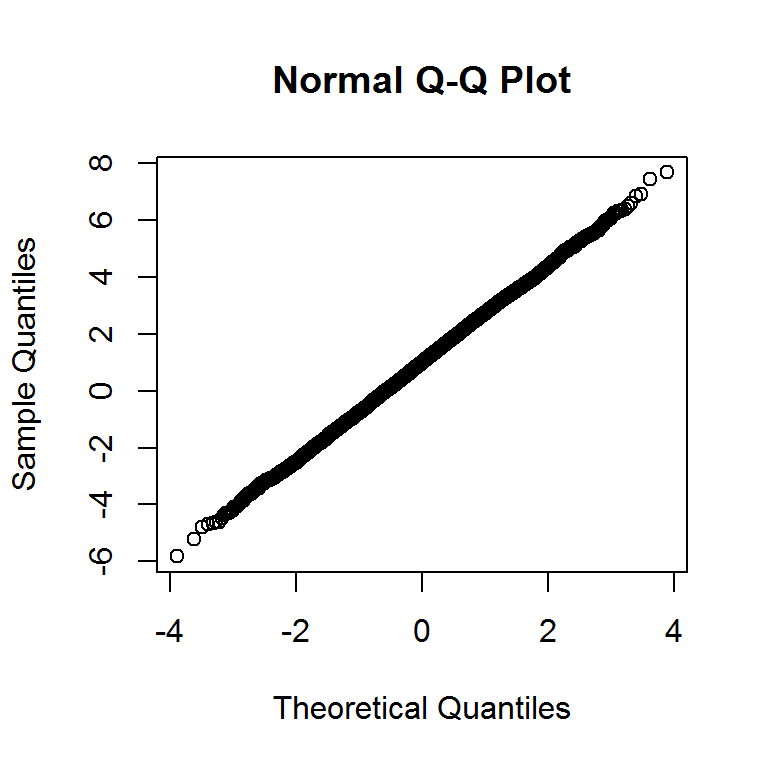

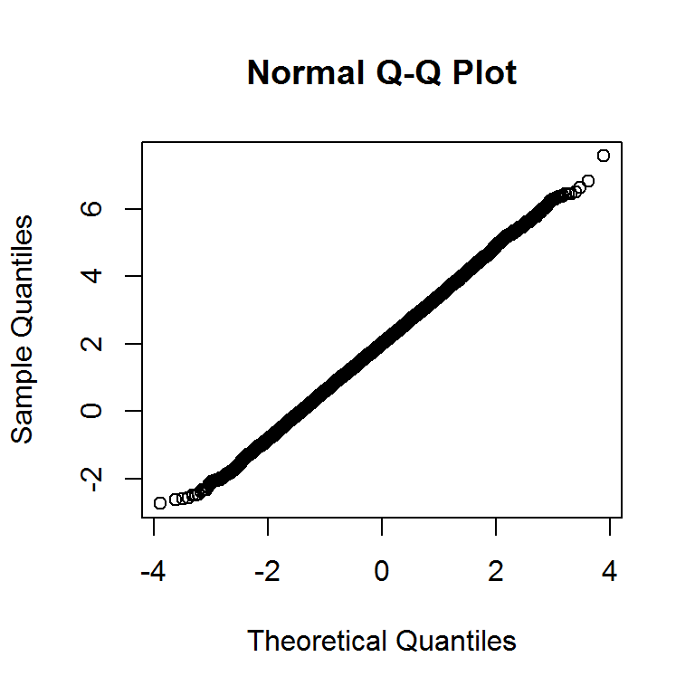

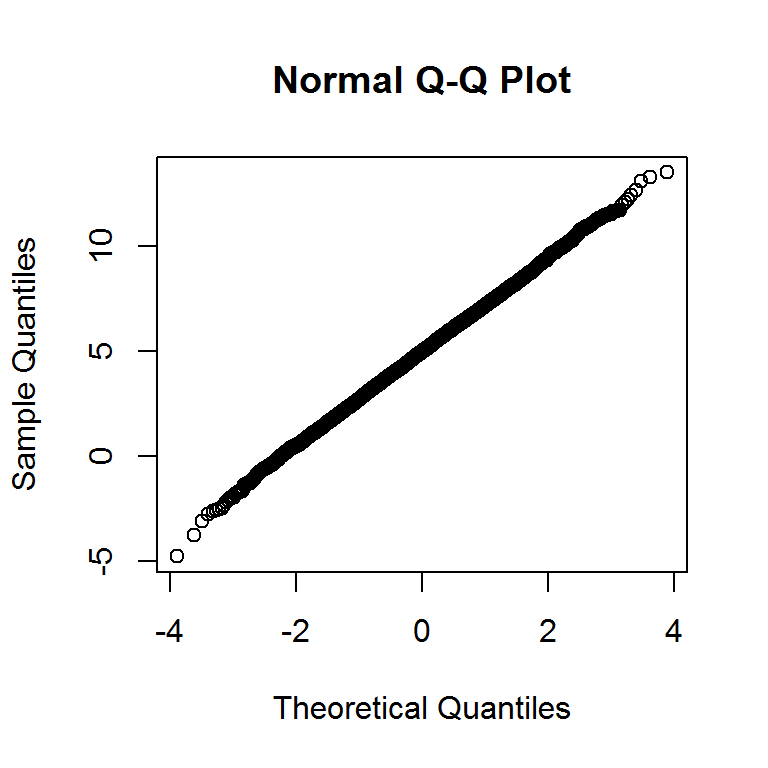

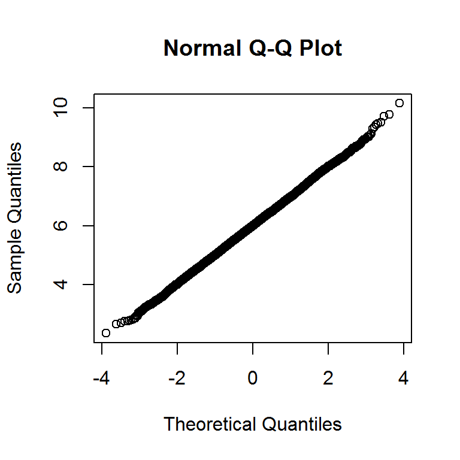

```r
# check normality
with(check_data, qqnorm(x[group==1]))
with(check_data, qqnorm(x[group==2]))
with(check_data, qqnorm(x[group==3]))
with(check_data, qqnorm(x[group==4]))
```

# 5 Estimation procedures

In the abstract, a function that implements an estimation procedure should have the following form:

```r
estimate <- function(sim_data) {

  # calculations/model-fitting/estimation procedures

  return(estimates)
}
```

The function takes a set of simulated data as input, fits a model or otherwise calculates a set of estimates, and produces as output a set estimates. The estimates could be point-estimates of parameters, standard errors, confidence intervals, etc. Depending on the research question, this function might involve use of a combination of several procedures (e.g., a diagnostic test for heteroskedasticity, followed by the conventional formula or heteroskedasticity-robust formula for standard errors). Also depending on the research question, we might need to create *several* functions that implement different estimation procedures to be compared.

## 5.1 heteroskedastic ANOVA

Brown and Forsythe considered four different hypothesis testing procedures for heteroskedastic ANOVA. For starters, let’s look at the simplest one, which is just to use a conventional one-way ANOVA (while mistakenly assuming homoskedasticity). The `oneway.test` function will calculate this test automatically:

```r
sim_data <- generate_data(mu = mu, sigma_sq = sigma_sq, sample_size = sample_size)
oneway.test(x ~ factor(group), data = sim_data, var.equal = TRUE)
```

```
##
##  One-way analysis of means
##
## data:  x and factor(group)
## F = 18.542, num df = 3, denom df = 11, p-value = 0.0001305
```

The main result we need here is the p-value, which will let us assess the test’s Type-I error and power for a given nominal $\alpha$-level. The following function takes simulated data as input and returns as output the p-value from a one-way ANOVA:

```r
ANOVA_F_aov <- function(sim_data) {
  oneway_anova <- oneway.test(x ~ factor(group), data = sim_data, var.equal = TRUE)
  return(oneway_anova$p.value)
}

ANOVA_F_aov(sim_data)
```

```
## [1] 0.0001304635
```

An alternative approach would be to program the ANOVA F statistic and test directly. Following the formulas on p. 129 of Brown and Forsythe (1974):

```r
ANOVA_F_direct <- function(sim_data) {

  x_bar <- with(sim_data, tapply(x, group, mean))
  s_sq <- with(sim_data, tapply(x, group, var))
  n <- table(sim_data$group)
  g <- length(x_bar)

  df1 <- g - 1
  df2 <- sum(n) - g

  msbtw <- sum(n * (x_bar - mean(sim_data$x))^2) / df1
  mswn <- sum((n - 1) * s_sq) / df2
  fstat <- msbtw / mswn
  pval <- pf(fstat, df1, df2, lower.tail = FALSE)

  return(pval)
}

ANOVA_F_direct(sim_data)
```

```
## [1] 0.0001304635
```

This approach takes more work to program, but will end up being quicker to compute. To see the difference, we’ll use an R package called `microbenchmark` to test how long the computations take for each version of the function. The `microbenchmark` function runs each expression 100 times (by default) and tracks how long the computations take. It then summarizes the distribution of timings:

```r
library(microbenchmark)
timings <- microbenchmark(Rfunction = ANOVA_F_aov(sim_data),
                          direct    = ANOVA_F_direct(sim_data))
timings
```

```
## Unit: microseconds
##       expr     min       lq     mean    median        uq      max neval
##  Rfunction 904.708 1105.607 1457.819 1443.1615 1691.9560 4512.516   100
##     direct 460.717  545.866  760.107  687.0845  890.4535 2774.565   100
```

The direct function is 1.9 times faster than the built-in R function.

This result is pretty typical. Built-in R functions usually include lots of checks and error-handling, which take time to compute. These checks are crucial for messy, real-world data analysis but unnecessary with our pristine, simulated data. Here we can skip them by doing the calculations directly.

Now let’s consider another one of the tests considered by Brown and Forsythe. Here is a function that calculates the Welch test, again following the notation and formulas from the paper:

```r
Welch_F <- function(sim_data) {

  x_bar <- with(sim_data, tapply(x, group, mean))
  s_sq <- with(sim_data, tapply(x, group, var))
  n <- table(sim_data$group)
  g <- length(x_bar)

  w <- n / s_sq
  u <- sum(w)
  x_tilde <- sum(w * x_bar) / u
  msbtw <- sum(w * (x_bar - x_tilde)^2) / (g - 1)

  G <- sum((1 - w / u)^2 / (n - 1))
  denom <- 1 +  G * 2 * (g - 2) / (g^2 - 1)
  W <- msbtw / denom
  f <- (g^2 - 1) / (3 * G)

  pval <- pf(W, df1 = g - 1, df2 = f, lower.tail = FALSE)

  return(pval)
}

Welch_F(sim_data)
```

```
## [1] 0.00821462
```

## 5.2 Efficiency considerations

Computational efficiency is usually a secondary consideration when you’re starting to design a simulation study. It’s better to produce accurate code, even if it’s a bit slow, than to use write code that is speedy but hard to follow (or even worse, that produces incorrect results). All that said, there is some glaring redundancy in the two functions we’ve looked at so far. Both of them start by taking the simulated data and calculating summary statistics for each group, using the following code:

```r
x_bar <- with(sim_data, tapply(x, group, mean))
s_sq <- with(sim_data, tapply(x, group, var))
n <- table(sim_data$group)
g <- length(x_bar)
```

In the interest of not repeating ourselves, it would better to pull this code out as a separate function and then re-write the `ANOVA_F` and `Welch_F` functions to take the summary statistics as input. Here is a function that takes simulated data and returns a list of summary statistics:

```r
summarize_data <- function(sim_data) {

  x_bar <- with(sim_data, tapply(x, group, mean))
  s_sq <- with(sim_data, tapply(x, group, var))
  n <- table(sim_data$group)
  g <- length(x_bar)

  return(list(x_bar = x_bar, s_sq = s_sq, n = n, g = g))
}

summarize_data(sim_data)
```

```
## $x_bar
##           1           2           3           4
## -0.09408853  1.56244431  5.90123293  5.88441816
##
## $s_sq
##         1         2         3         4
## 0.3963165 1.9161675 1.6500254 2.0045610
##
## $n
##
## 1 2 3 4
## 3 6 2 4
##
## $g
## [1] 4
```

Now we can re-write the F-test functions to use the output of this function:

```r
ANOVA_F <- function(x_bar, s_sq, n, g) {

  df1 <- g - 1
  df2 <- sum(n) - g

  msbtw <- sum(n * (x_bar - weighted.mean(x_bar, w = n))^2) / df1
  mswn <- sum((n - 1) * s_sq) / df2
  fstat <- msbtw / mswn
  pval <- pf(fstat, df1, df2, lower.tail = FALSE)

  return(pval)
}

summary_stats <- summarize_data(sim_data)
with(summary_stats, ANOVA_F(x_bar = x_bar, s_sq = s_sq, n = n, g = g))
```

```
## [1] 0.0001304635
```

```r
Welch_F <- function(x_bar, s_sq, n, g) {

  w <- n / s_sq
  u <- sum(w)
  x_tilde <- sum(w * x_bar) / u
  msbtw <- sum(w * (x_bar - x_tilde)^2) / (g - 1)

  G <- sum((1 - w / u)^2 / (n - 1))
  denom <- 1 +  G * 2 * (g - 2) / (g^2 - 1)
  W <- msbtw / denom
  f <- (g^2 - 1) / (3 * G)

  pval <- pf(W, df1 = g - 1, df2 = f, lower.tail = FALSE)

  return(data.frame(W = W, f = f, pval = pval))
}

with(summary_stats, Welch_F(x_bar = x_bar, s_sq = s_sq, n = n, g = g))
```

```
##          W        f       pval
## 1 19.97661 3.840882 0.00821462
```

The results are the same as before.

## 5.3 Checking the estimation function(s)

Just as with the data-generating function, it is important to verify the accuracy of the estimation functions. For the ANOVA-F test, this can be done simply by checking the result of `ANOVA_F` against the built-in `oneway.test` function. Let’s do that with a fresh set of data:

```r
sim_data <- generate_data(mu = mu, sigma_sq = sigma_sq, sample_size = sample_size)
aov_results <- oneway.test(x ~ factor(group), data = sim_data, var.equal = TRUE)
aov_results
```

```
##
##  One-way analysis of means
##
## data:  x and factor(group)
## F = 11.581, num df = 3, denom df = 11, p-value = 0.0009931
```

```r
summary_stats <- summarize_data(sim_data)
F_results <- with(summary_stats, ANOVA_F(x_bar = x_bar, s_sq = s_sq, n = n, g = g))
F_results
```

```
## [1] 0.0009931014
```

```r
all.equal(aov_results$p.value, F_results)
```

```
## [1] TRUE
```

We can follow the same approach to check the results of the Welch test because it is also implemented in `oneway.test`:

```r
aov_results <- oneway.test(x ~ factor(group), data = sim_data, var.equal = FALSE)
aov_results
```

```
##
##  One-way analysis of means (not assuming equal variances)
##
## data:  x and factor(group)
## F = 16.358, num df = 3.0000, denom df = 3.0564, p-value = 0.02198
```

```r
W_results <- with(summary_stats, Welch_F(x_bar = x_bar, s_sq = s_sq, n = n, g = g))
W_results
```

```
##          W        f       pval
## 1 16.35815 3.056441 0.02198328
```

```r
all.equal(aov_results$p.value, W_results$pval)
```

```
## [1] TRUE
```

Checking estimation functions can be a bit more difficult for procedures that are not already implemented in R. For example, the two other procedures examined by Brown and Forsythe, the James’ test and Brown and Forsythe’s $F*$ test, are not available in base R. They are available in the user-contributed package `onewaytests` (I found this by searching for “Brown-Forsythe” at http://rseek.org/). We could benchmark our calculations against this package, but of course there is some risk that the package might not be correct. Another route is to verify your results on numerical examples reported in authoritative papers, on the assumption that there’s less risk of an error there. In the original paper that proposed the test, Welch (1951) provides a worked numerical example of the procedure. He reports the following summary statistics:

```r
g <- 3
x_bar <- c(27.8, 24.1, 22.2)
s_sq <- c(60.1, 6.3, 15.4)
n <- c(20, 20, 10)
```

He also reports $W = 3.35$ and $f = 22.6$. Replicating the calculations with our `Welch_F` function:

```r
Welch_F(x_bar = x_bar, s_sq = s_sq, n = n, g = g)
```

```
##          W        f       pval
## 1 3.344116 21.06575 0.05479049
```

We get slightly different results! But we know that our function is correct—or at least consistent with `oneway.test`—so what’s going on? It turns out that there was an error in some of Welch’s intermediate calculations, which can only be spotted because he reported all of his work in the paper.

# 6 Replicate

We now have functions that implement steps 2 and 3 of the simulation. Starting with the parameters, `generate_data` produces a simulated dataset; `summarize_data` calculates summary statistics for the simulated data; and `ANOVA_F` and `Welch_F` use the simulated summary statistics to calculate p-values. To evaluate the accuracy of these tests, we now need to repeat this chain of calculations a bunch of times.

R includes a function called `replicate` that will be very handy as we design and implement simulations. The function does what its name suggests—it replicates the result of an expression a specified number of times. The first argument is the number of times to replicate and the next argument is an expression (a short piece of code to run). A further argument, `simplify` allows you to control how the results are structured. Setting `simplify = FALSE` returns the output as a list. The following code produces 4 replications of the simulated dataset:

```r
sim_data <- replicate(n = 4,
                      generate_data(mu = mu, sigma_sq = sigma_sq, sample_size = sample_size),
                      simplify = FALSE)
str(sim_data)
```

```
## List of 4
##  $ :'data.frame':    15 obs. of  2 variables:
##   ..$ group: int [1:15] 1 1 1 2 2 2 2 2 2 3 ...
##   ..$ x    : num [1:15] 1.004 1.9 0.912 1.893 1.846 ...
##  $ :'data.frame':    15 obs. of  2 variables:
##   ..$ group: int [1:15] 1 1 1 2 2 2 2 2 2 3 ...
##   ..$ x    : num [1:15] -0.748 -0.257 0.286 1.744 2.904 ...
##  $ :'data.frame':    15 obs. of  2 variables:
##   ..$ group: int [1:15] 1 1 1 2 2 2 2 2 2 3 ...
##   ..$ x    : num [1:15] 4.605 2.794 0.308 2.486 3.182 ...
##  $ :'data.frame':    15 obs. of  2 variables:
##   ..$ group: int [1:15] 1 1 1 2 2 2 2 2 2 3 ...
##   ..$ x    : num [1:15] 2.1071 0.0612 0.8523 -0.775 0.4241 ...
```

You can put multiple lines of code in the expression by enclosing them in curly brackets (`{}`). The following code produces 4 replications of the test statistics and p-value from Welch’s test:

```r
replicate(n = 4, {
  sim_data <- generate_data(mu = mu, sigma_sq = sigma_sq, sample_size = sample_size)
  summary_stats <- summarize_data(sim_data)
  with(summary_stats, Welch_F(x_bar = x_bar, s_sq = s_sq, n = n, g = g))
}, simplify = FALSE)
```

```
## [[1]]
##          W        f       pval
## 1 7.478214 3.333633 0.05577253
##
## [[2]]
##          W        f       pval
## 1 7.676393 3.257764 0.05588483
##
## [[3]]
##          W        f        pval
## 1 47.55501 3.325987 0.003239264
##
## [[4]]
##          W       f        pval
## 1 18.99662 4.30405 0.006186812
```

However, we need to get results from the ANOVA F-test as well. Let’s add that in and just return a data frame with p-values:

```r
replicate(n = 4, {
  sim_data <- generate_data(mu = mu, sigma_sq = sigma_sq, sample_size = sample_size)
  summary_stats <- summarize_data(sim_data)
  anova_p <- with(summary_stats, ANOVA_F(x_bar = x_bar, s_sq = s_sq, n = n, g = g))
  Welch <- with(summary_stats, Welch_F(x_bar = x_bar, s_sq = s_sq, n = n, g = g))
  data.frame(ANOVA = anova_p, Welch = Welch$pval)
}, simplify = FALSE)
```

```
## [[1]]
##         ANOVA      Welch
## 1 0.001831407 0.01246369
##
## [[2]]
##          ANOVA      Welch
## 1 0.0001879519 0.01825643
##
## [[3]]
##        ANOVA      Welch
## 1 0.01974294 0.05799589
##
## [[4]]
##        ANOVA      Welch
## 1 0.02397958 0.04981728
```

The `bind_rows` function from the `dplyr` package will turn this list into a data frame, for easier manipulation:

```r
library(dplyr)

p_vals <- replicate(n = 4, {
  sim_data <- generate_data(mu = mu, sigma_sq = sigma_sq, sample_size = sample_size)
  summary_stats <- summarize_data(sim_data)
  anova_p <- with(summary_stats, ANOVA_F(x_bar = x_bar, s_sq = s_sq, n = n, g = g))
  Welch <- with(summary_stats, Welch_F(x_bar = x_bar, s_sq = s_sq, n = n, g = g))
  data.frame(ANOVA = anova_p, Welch = Welch$pval)
}, simplify = FALSE)

bind_rows(p_vals)
```

```
##          ANOVA       Welch
## 1 2.131907e-03 0.018053684
## 2 3.019830e-03 0.013035977
## 3 2.036837e-04 0.020683866
## 4 1.193594e-05 0.001055204
```

Simulated p-values!

## 6.1 Calculating rejection rates

We’ve got all the pieces in place now to reproduce the results from Brown and Forsythe (1974). Let’s focus on calculating the actual type-I error rate of these tests—that is, the proportion of the time that they reject the null hypothesis of equal means when that null is actually true—for an $\alpha$-level of .05. We therefore need to simulate data according to process where the population means are indeed all equal. Arbitrarily, let’s look at $g = 4$ groups and set all of the means equal to zero:

```r
mu <- rep(0, 4)
```

In the fifth row of Table 1, they examine performance for the following parameter values for sample size and population variance:

```r
sample_size <- c(4, 8, 10, 12)
sigma_sq <- c(3, 2, 2, 1)^2
```

With these parameter values, we can use our `replicate` code to simulate 10,000 p-values:

```r
p_vals <- replicate(n = 10000, {
  sim_data <- generate_data(mu = mu, sigma_sq = sigma_sq, sample_size = sample_size)
  summary_stats <- summarize_data(sim_data)
  anova_p <- with(summary_stats, ANOVA_F(x_bar = x_bar, s_sq = s_sq, n = n, g = g))
  Welch <- with(summary_stats, Welch_F(x_bar = x_bar, s_sq = s_sq, n = n, g = g))
  data.frame(ANOVA = anova_p, Welch = Welch$pval)
}, simplify = FALSE)

p_vals <- bind_rows(p_vals)
head(p_vals)
```

```
##       ANOVA     Welch
## 1 0.3932604 0.6486675
## 2 0.6572806 0.5295222
## 3 0.2913016 0.3021003
## 4 0.4175835 0.7365519
## 5 0.9237816 0.7096286
## 6 0.1163067 0.2584378
```

Now how to calculate the rejection rates? The rule is that the null is rejected if the p-value is less than $\alpha$. To get the rejection rate, calculate the proportion of replications where the null is rejected. This is equivalent to taking the mean of the logical conditions:

```r
mean(p_vals$ANOVA < .05)
```

```
## [1] 0.1447
```

We get a rejection rate that is much larger than $\alpha = .05$, which indicates that the ANOVA F-test does not adequately control Type-I error under this set of conditions.

```r
mean(p_vals$Welch < .05)
```

```
## [1] 0.0655
```

The Welch test does much better, although it is still a little bit in excess of .05.

Note that these two numbers are quite close (though not quite identical) to the corresponding entries in Table 1 of Brown and Forsythe (1974). The difference is due to the fact that both Table 1 and are results are actually *estimated* rejection rates, because we haven’t actually simulated an infinite number of replications. The estimation error arising from using a finite number of replications is called *simulation error* (or *Monte Carlo error*). In a later class, we’ll look more at how to estimate and control the simulation error in our studies.

```r
save(p_vals, file = "Brown-Forsythe-pvals.RData")
```